# Community Perception Survey 2024

16 September 2024

# Analysis Plan

```
#> no calculated indicators has been defined...
```

# Automatic Exploration

Introduction `plot_text(datalist, dico, "introduction", datasource=params$datasource)`

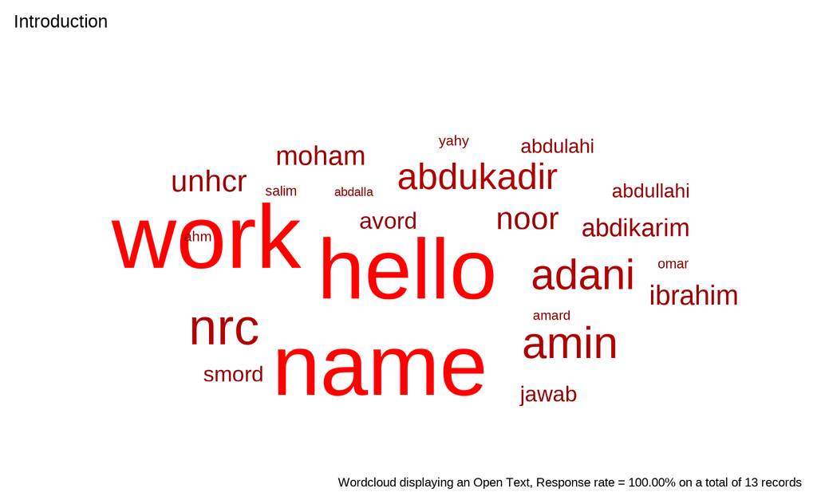

Location of KII `plot_text(datalist, dico, "location", datasource=params$datasource)`

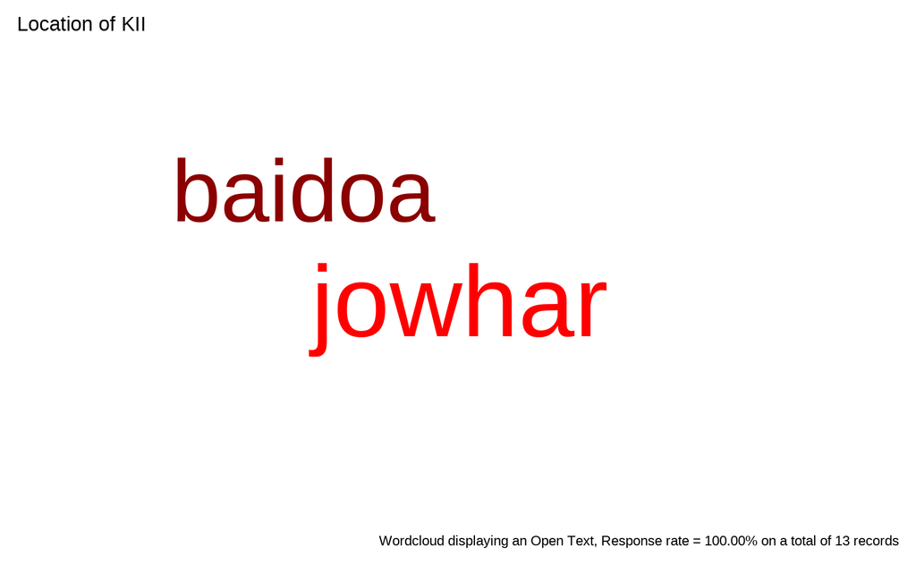

Do you agree to participate in this survey? `plot_select_one(datalist, dico, "consent", datasource = params$datasource, n = 5)`

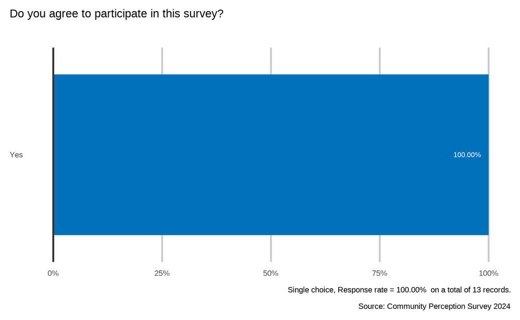

What is your age group? `plot_select_one(datalist, dico, "age_group", datasource = params$datasource, n = 5)`

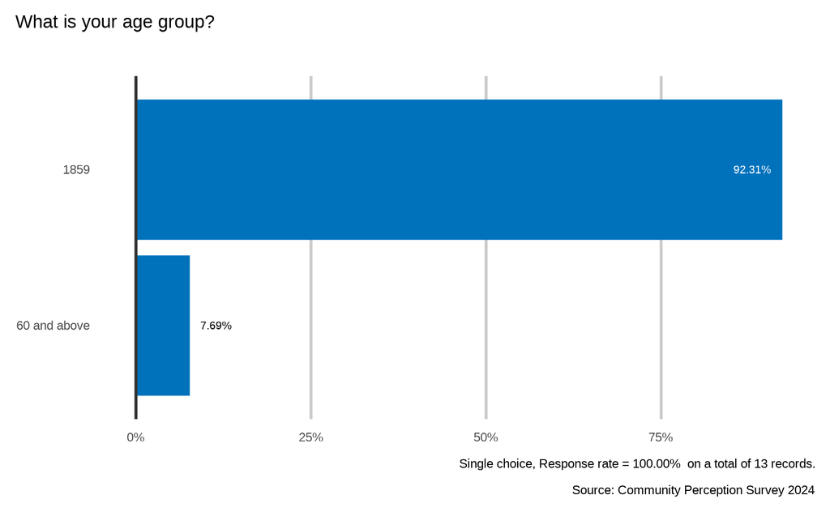

What is your gender? `plot_select_one(datalist, dico, "gender", datasource = params$datasource, n = 5)`

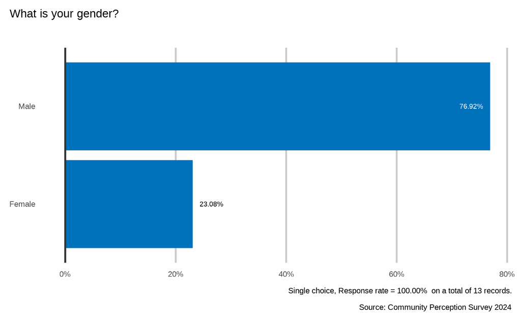

What is your role in the community? `plot_select_multiple(datalist, dico, "role", datasource=params$datasource, n=5)`

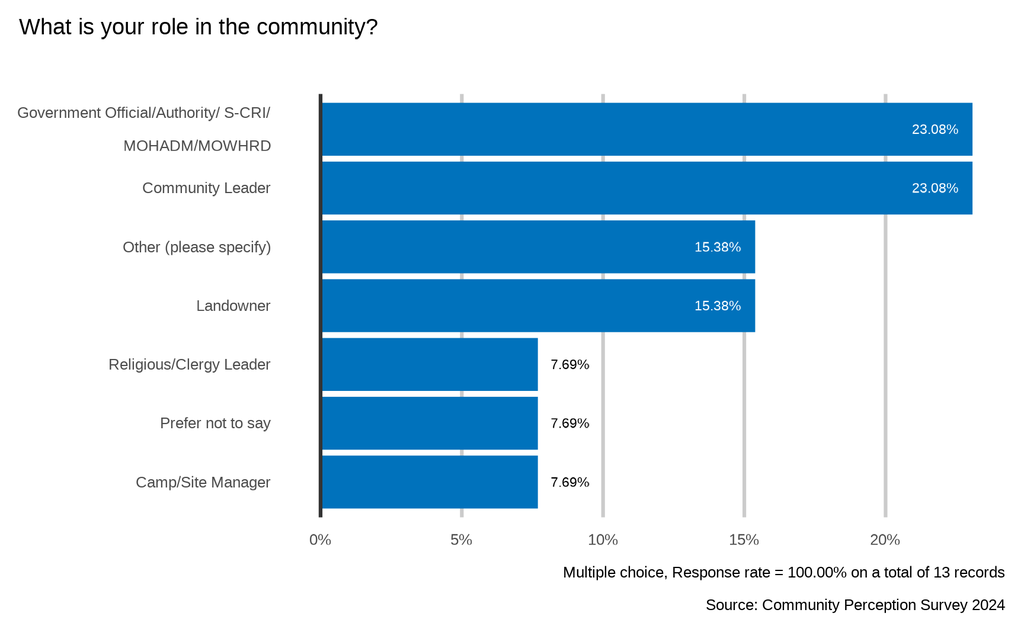

What sectors/clusters have provided assistance in your community? `plot_select_multiple(datalist, dico, "sectors", datasource=params$datasource, n=5)`

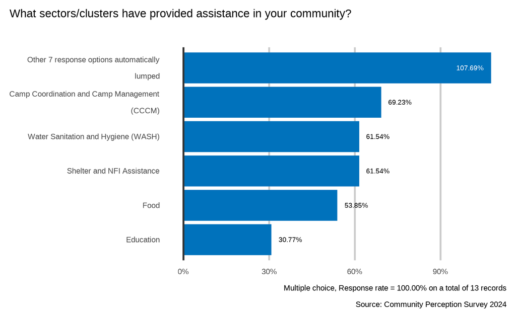

What are the main challenges marginalized or underrepresented groups face in receiving humanitarian assistance in your community? `plot_select_multiple(datalist, dico, "challenges", datasource=params$datasource, n=5)`

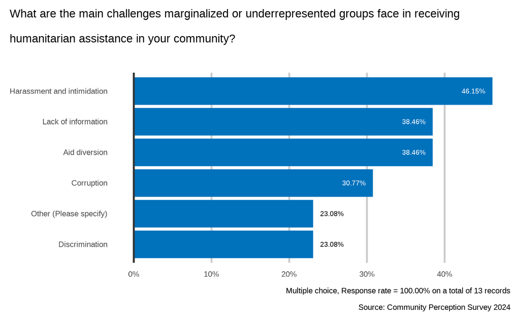

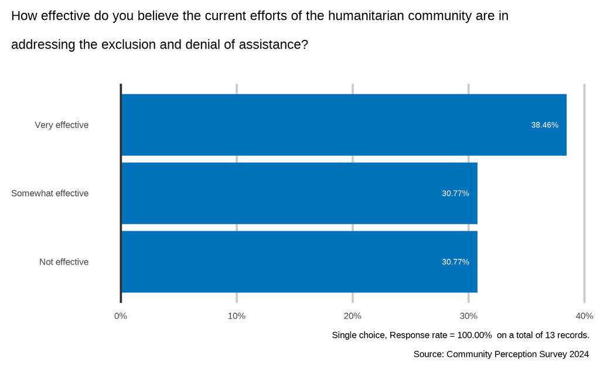

How would you rate the fairness and effectiveness of the current aid distribution for marginalized groups? `plot_select_one(datalist, dico, "fairness", datasource = params$datasource, n = 5)`

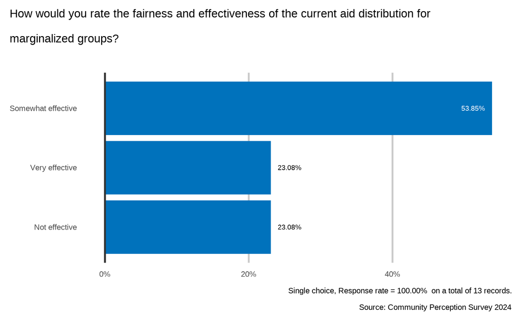

### What changes would you suggest to improve fairness and effectiveness in aid delivery ?

`plot_text(datalist, dico, "suggestions", datasource=params$datasource)` The Key Informant Interview (KII) participants offered several recommendations to improve the fairness and effectiveness of aid delivery. Key suggestions include:  
**1. Enhanced Targeting and Vulnerability Assessments:** Conducting thorough vulnerability assessments to ensure proper targeting and reaching marginalized groups, including those with specific needs, was frequently recommended. This would improve the selection of beneficiaries and ensure aid reaches those most in need.  
**2. Inclusive Aid Programs:** Aid delivery should focus on inclusivity and provide general protection assistance, rather than narrowly targeted sectoral aid. Programs like vocational skills training and business startup grants would promote self-reliance among marginalized groups.  
**3. Conditional Assistance:** Exploring conditional assistance rather than continuous unconditional cash transfers (UCT) could encourage greater self-sufficiency and reduce dependency.  
**4. Post-Distribution Monitoring:** Regular post-distribution monitoring should be conducted to assess the challenges and ensure fairness and accountability in the aid process. Monitoring would help identify gaps and improve future distributions.  
**5. Transparency and Accountability:** Clear, transparent selection criteria and accountability mechanisms are needed to prevent favoritism, corruption, and mismanagement. Aid distribution standards and a code of conduct should be followed strictly.  
**6. Independent Oversight:** Involving independent third-party organizations to monitor and evaluate aid programs would enhance accountability and reduce corruption.  
**7. Mobile Distribution Points:** Implementing mobile or local distribution centers would reduce the distance beneficiaries must travel, especially for those in remote areas, improving access.  
**8. Information Dissemination:** Clear and timely information about aid availability, distribution schedules, and criteria should be provided to all beneficiaries, ensuring that everyone is aware of their entitlements.  
**9. Capacity Development:** Capacity-building programs, such as vocational training and livelihood sustainability initiatives, would help marginalized groups become self-reliant and contribute to community development.  
**10. Regular Monitoring and Evaluation:** Regular assessments and data-driven decision-making should guide aid distribution to ensure that it is fair, efficient, and responsive to emerging needs.  
**In summary, the recommendations focus on improving targeting, transparency, monitoring, and accountability, while also promoting self-reliance and inclusivity in aid programs through better communication, assessment, and capacity-building efforts.**  
What are the most significant risks faced by displaced individuals/groups in your community? `plot_select_multiple(datalist, dico, "risks", datasource=params$datasource, n=5)`

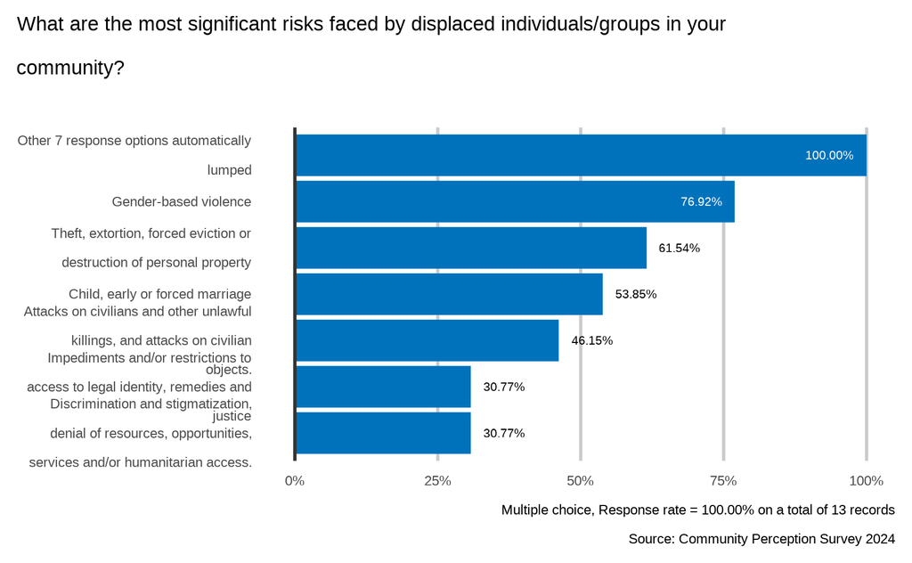

### What coping mechanisms have marginalized individuals or families employed to manage their situation?

`plot_text(datalist, dico, "coping_mechanisms", datasource=params$datasource)` The KII responses highlighted various coping mechanisms employed by marginalized individuals or families to manage their situations. Key strategies include:  
**Casual Labor and Low-Paying Jobs:** Many marginalized individuals engage in casual labor such as construction work, fetching and selling firewood, and washing clothes to earn wages.  
**Begging:** In some cases, the most vulnerable resort to begging for help, especially in markets or public areas, as a last resort to survive.  
**Vocational Training:** Some marginalized groups seek opportunities for vocational training to acquire technical skills, enhancing their ability to work and generate income, promoting self-reliance.  
**Microfinance and Entrepreneurship Support:** Access to microfinance initiatives and entrepreneurship support helps individuals start small businesses or engage in income-generating activities to manage their livelihoods.  
**Agriculture Initiatives:** Marginalized families may participate in agriculture-related activities, such as community gardens or modern farming techniques, to ensure food security and income generation.  
**Information Technology Training:** Learning IT skills, including computer literacy, coding, and software development, can increase employability, especially in the digital economy.  
**Government Assistance and Advocacy:** Some individuals apply for government assistance programs, learn about their rights, and engage in advocacy movements to raise awareness and demand policy changes for better support.  
**Lack of External Support:** Several responses noted the absence of formal coping mechanisms provided by external organizations or within the community, leaving individuals to rely primarily on their own efforts.  
**In summary, marginalized individuals rely on informal labor, vocational training, entrepreneurship, and, in some cases, begging or advocacy to cope with their challenges, though many lack access to established support systems.**

### Are these coping strategies sustainable?

`plot_text(datalist, dico, "coping_strategies_sustainable", datasource=params$datasource)` The KII responses indicate mixed opinions on the sustainability of the coping strategies used by marginalized individuals. Key points include:  
**Unsustainable Strategies:** Many participants believe that the current coping mechanisms are not sustainable due to their scarcity, limitations, and the lack of resources. Strategies like casual labor and begging do not provide long-term stability.  
**Sustainability of Skills-Based Approaches:** Some participants highlighted that vocational training and technical skills acquisition are more sustainable, as they equip individuals with the tools to earn an income and support their families, reducing poverty.  
**Support from Humanitarian Agencies:** A few respondents noted that humanitarian agencies provide essential services that help mitigate some challenges, but the support is limited and may not fully address long-term needs.  
**Human Connection:** One response mentioned that coping strategies may not be sustainable because humans need more than survival skills—they need communication and connection with each other for holistic well-being.  
**In summary, while skills-based coping mechanisms, such as vocational training, are viewed as more sustainable, the overall consensus is that many of the current strategies are unsustainable due to resource limitations and a lack of long-term support.**

### Has the Humanitarian Community effectively implemented programs to help alleviate these risks?

`plot_select_one(datalist, dico, "effectiveness_program", datasource = params$datasource, n = 5)`

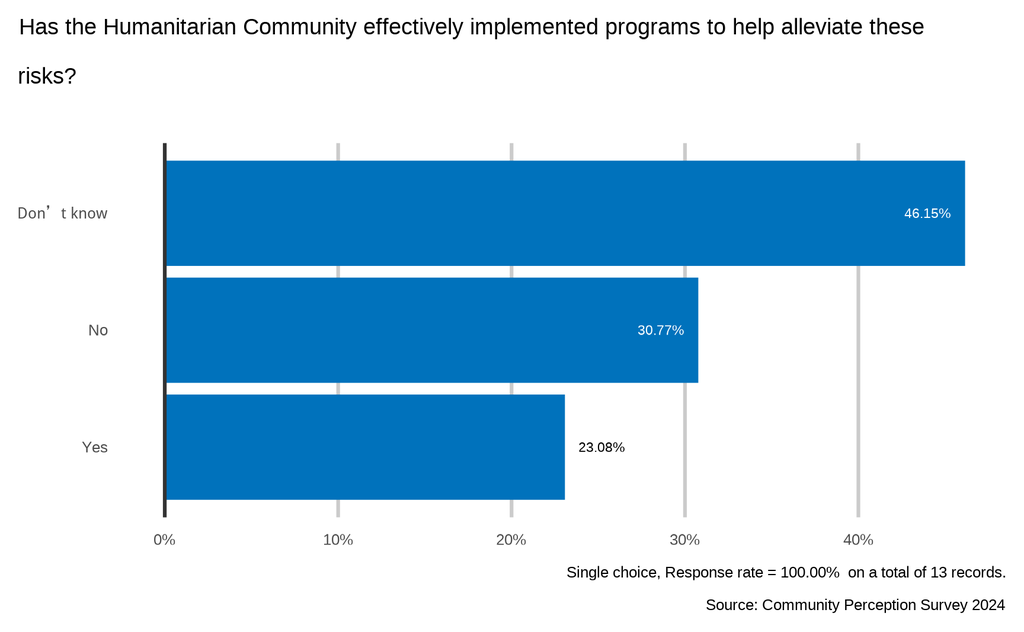

Have there been any incidents of violence or discrimination against members in your community? `plot_select_one(datalist, dico, "incidents", datasource = params$datasource, n = 5)`

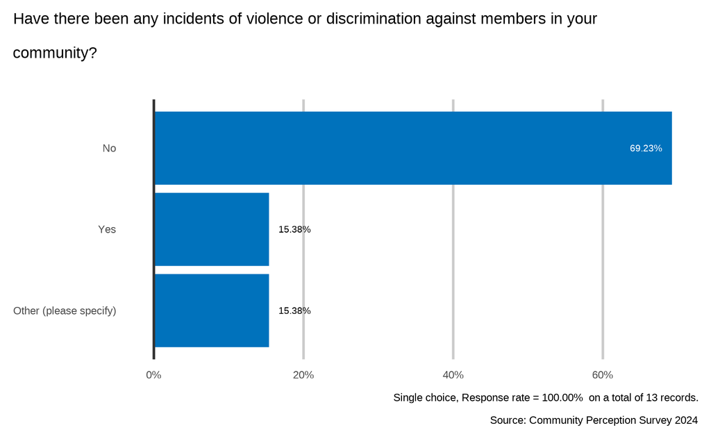

### What impact did these incidents have and what measures have been taken to protect these groups?

`plot_text(datalist, dico, "impact_measures", datasource=params$datasource)` The KII responses highlighted several significant impacts of incidents, as well as measures taken (or not taken) to protect marginalized groups. Key points include:

#### **Impacts:**

**Physical Harm:** Many incidents have resulted in physical violence, leading to injuries and trauma among affected individuals.  
**Emotional and Psychological Effects:** Victims of violence face emotional and psychological distress, further exacerbating their vulnerability.  
**Social Isolation and Stigmatization:** Victims, particularly those subjected to violence or discrimination, often experience social isolation and stigmatization, which affects their mental health and social interactions.  
**Community Disunity:** Violence and incidents have led to disunity within communities, causing mistrust, poor communication, and a breakdown of social cohesion. Misunderstandings and hatred among groups exacerbate tensions.  
**Lack of Protection:** In cases like rape, no measures have been taken to protect victims, highlighting the lack of adequate protection mechanisms for those most vulnerable.

#### **Measures Taken or Suggested:**

**Improved Community Integration:** A key recommendation is the need for better integration and coordination between communities and internally displaced persons (IDPs) to foster trust and unity.  
**Conflict Resolution and Dialogue:** Communities should engage in open discussions and negotiations to resolve misunderstandings, reduce tensions, and rebuild trust among groups.  
**Removing Hatred and Disunity:** To achieve peace and prevent further violence, communities are encouraged to eliminate hatred and work toward unity, avoiding discrimination and fighting.  
**In summary, the incidents have caused physical, emotional, and social harm, leading to disunity and mistrust within communities. While some measures have been suggested, such as improving integration, dialogue, and trust-building, there remains a lack of concrete action, particularly in cases of severe violence like rape.**

### What specific recommendations do you have for improving humanitarian aid and protection efforts in your community?

`plot_text(datalist, dico, "specifc_recommendations", datasource=params$datasource)`

#### Enhance Accessibility and Reach

The KII responses provided several recommendations for improving humanitarian aid and protection efforts in the community. Key suggestions include:

#### Enhance Accessibility and Reach:

- Increase the number of aid distribution points to make it easier for people to access supplies.
- Deploy mobile clinics and services to reach remote or underserved areas.

#### Improve Fairness and Inclusivity:

- Ensure transparent and fair aid distribution processes, with clear criteria to prevent favoritism and corruption.
- Involve marginalized and vulnerable groups in the planning and implementation of aid programs to address their specific needs.
- Provide equal treatment to all beneficiaries, eliminating discrimination and corruption.

#### Capacity Building:

- Train local volunteers and organizations in disaster response, first aid, and emergency preparedness.
- Provide vocational training and livelihood programs to help communities become self-sufficient and recover from crises.

#### Strengthen Protection Measures:

- Establish safe spaces and anti-discrimination policies to protect vulnerable groups, especially women and children.
- Create and promote feedback and complaint mechanisms to allow beneficiaries to voice concerns and suggest improvements.
- Set up hotlines or communication channels for beneficiaries to report incidents and access support.

#### Localizing Aid Efforts:

- Encourage the localization of aid by empowering local markets and engaging local NGOs and companies in procurement and service delivery.
- Collaborate with the government to improve access to hard-to-reach areas, reducing the influx of IDPs to aid hubs.

#### Monitoring and Accountability:

- Implement ongoing monitoring of aid distribution to assess fairness and effectiveness.
- Conduct post-distribution monitoring to identify challenges and improve future aid delivery.
- Involve independent third-party organizations to monitor aid programs and ensure accountability.

#### Education and Livelihood Support:

- Provide educational support to children and adults affected by crises to minimize disruption to their learning.
- Support agriculture and vocational training to promote self-reliance and improve livelihoods for marginalized groups.

**In summary, the key recommendations focus on improving access, fairness, inclusivity, protection, and localizing aid efforts while promoting transparency, monitoring, and self-sufficiency within the community.**  
Would you like to receive an update on the survey results and the UN’s response? `plot_select_one(datalist, dico, "update", datasource = params$datasource, n = 5)`

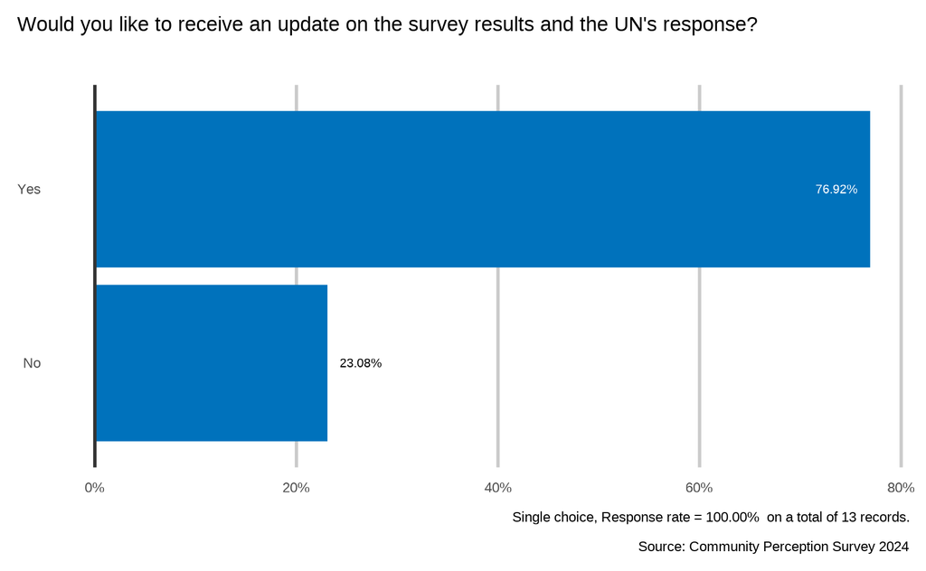

# Summary Likert Charts

1 groups of likert questions in the form`plot_likert(datalist, dico, scopei="", list_namei="effectiveness", repeatvari="main",datasource=params$datasource)`

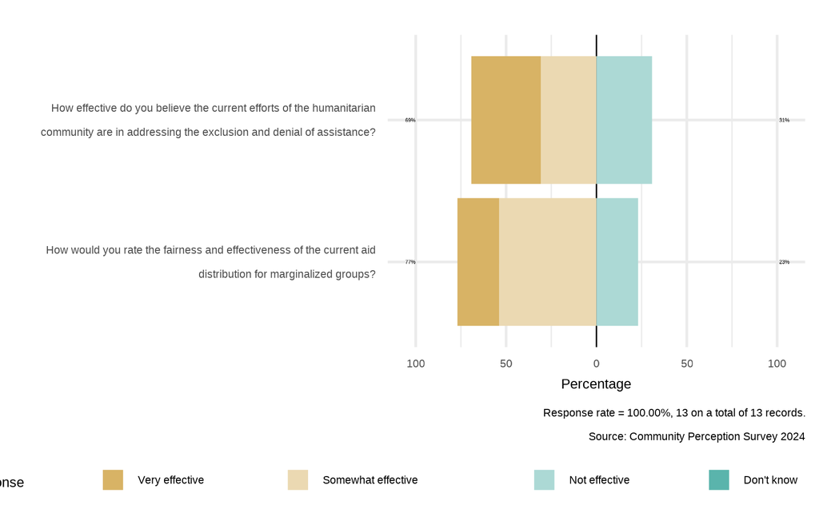

## Annex: Crunching step

This data crunching report allows to quickly explore the results of the survey published in [RIDL](https://ridl.unhcr.org/dataset/ridlproject). It can be regenerated as needed based on the analysis plan you did set up. The objective of this report is to allow to quickly identify potential patterns in your dataset. A quick screening of this initial report should allow to select the most meaningful graphs.

The crunching process produces a lot of visuals. Therefore it is key to carefully select the most relevant visual that will be presented for potential interpretation in the next step. To do so, you simply copy-paste the short syntax in a second notebook to generate as powerpoint presentation. A typical data interpretation session shall not last more than 2hours and include more than 60 visuals to look at in order to keep participants with a good focus level.

In order to guide this selection phase, data experts, in collaboration with the data analysis group, can use the following elements:

- For numeric value, check the frequency distributions of each variable to average, deviation, including outlier and oddities
- For categorical variables, check for unexpected values: any weird results based on common sense expectations
- Use correlation analysis to check for potential contradictions in respondents answers to different questions for identified associations (chi-square)
- Always, Check for missing data (NA) or “%of respondent who answered” that you cannot confidently explain
- Check unanswered questions, that corresponds to unused skip logic in the questionnaire: For instance, did a person who was never displaced answer displacement-related questions? Were employment-related answers provided for a toddler?

When analyzing those representations in a collective setting during data interpretation sessions, you may:

1. **Reflect**: question data quality and/or make suggestions to adjust questions, identify additional cleaning steps;
2. **Interpret**: develop qualitative interpretations of data patterns;
3. **Recommend**: suggest recommendations in terms of programmatic adjustment;
4. **Classify**: define level of sensitivity for certain topics if required;

The report can be regenerated as needed by:

- adjusting the report configuration in the xlsform to break it into report and chapter;
- configuring disaggregation & correlation for each question;
- revising the data cleansing based on the cleaning log;
- appending calculated indicators to your data frame to reshape variable - also called feature engineering.